# Dimensionality reduction techniques (Chapter 5)

### Task 2. Performing principal component analysis (PCA) on the not standardized human data

```r
# performing PCA  analysis on the unstandardized data
pca_human <- prcomp(human)

# Show the variability captured by the PCA
summary(pca_human)
```

```
## Importance of components:
##                              PC1      PC2   PC3   PC4   PC5   PC6    PC7    PC8
## Standard deviation     1.854e+04 185.5219 25.19 11.45 3.766 1.566 0.1912 0.1591
## Proportion of Variance 9.999e-01   0.0001  0.00  0.00 0.000 0.000 0.0000 0.0000
## Cumulative Proportion  9.999e-01   1.0000  1.00  1.00 1.000 1.000 1.0000 1.0000
```

```r
pca_human
```

```
## Standard deviations (1, .., p=8):
## [1] 1.854416e+04 1.855219e+02 2.518701e+01 1.145441e+01 3.766241e+00
## [6] 1.565912e+00 1.912052e-01 1.591112e-01
##
## Rotation (n x k) = (8 x 8):
##                     PC1           PC2           PC3           PC4           PC5
## Edu2.FM   -5.607472e-06  0.0006713951 -3.412027e-05 -2.736326e-04 -0.0022935252
## Labo.FM    2.331945e-07 -0.0002819357  5.302884e-04 -4.692578e-03  0.0022190154
## Edu.Exp   -9.562910e-05  0.0075529759  1.427664e-02 -3.313505e-02  0.1431180282
## Life.Exp  -2.815823e-04  0.0283150248  1.294971e-02 -6.752684e-02  0.9865644425
## GNI       -9.999832e-01 -0.0057723054 -5.156742e-04  4.932889e-05 -0.0001135863
## Mat.Mor    5.655734e-03 -0.9916320120  1.260302e-01 -6.100534e-03  0.0266373214
## Ado.Birth  1.233961e-03 -0.1255502723 -9.918113e-01  5.301595e-03  0.0188618600
## Parli.F   -5.526460e-05  0.0032317269 -7.398331e-03 -9.971232e-01 -0.0716401914
##                     PC6           PC7           PC8
## Edu2.FM    2.180183e-02  6.998623e-01  7.139410e-01
## Labo.FM    3.264423e-02  7.132267e-01 -7.001533e-01
## Edu.Exp    9.882477e-01 -3.826887e-02  7.776451e-03
## Life.Exp  -1.453515e-01  5.380452e-03  2.281723e-03
## GNI       -2.711698e-05 -8.075191e-07 -1.176762e-06
## Mat.Mor    1.695203e-03  1.355518e-04  8.371934e-04
## Ado.Birth  1.273198e-02 -8.641234e-05 -1.707885e-04
## Parli.F   -2.309896e-02 -2.642548e-03  2.680113e-03
```

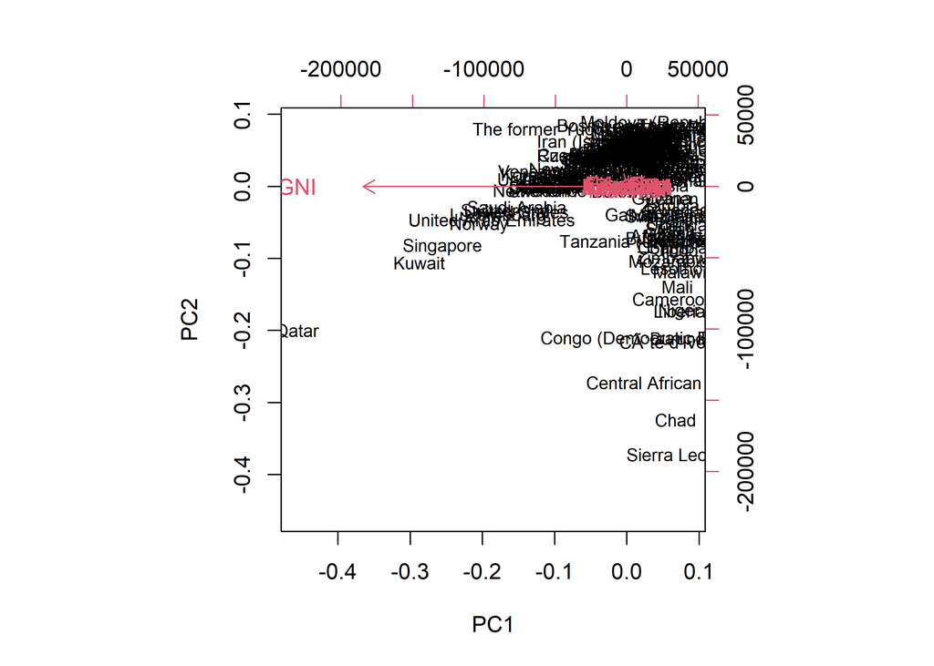

```r
# Let us plot the biplot displaying the observations by the first two principal components
biplot(pca_human, choices = 1:2, cex = c(0.8, 1))
```

```r
#biplot(pca_human, choices = 1:2)
```

Figure 2. PCA plot of unstandardised data

### Task 3. Performing principal component analysis (PCA) on the standardized human data

[output not shown]

[output not shown]

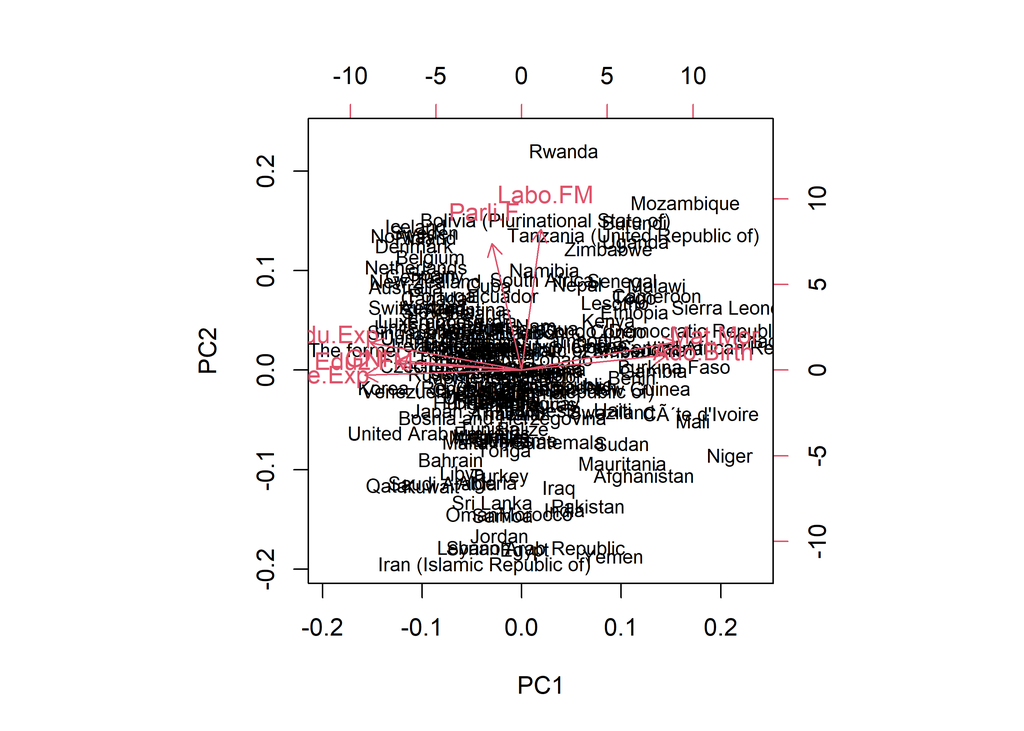

```r
# Let us plot the biplot displaying the observations by the first two principal components
biplot(pca_human, choices = 1:2, cex = c(0.8, 1))
```

Figure 2. PCA plot of standardised data

#### Explanation of the two visualization

We observe that the two results of PCA in the plots are significantly different. The unstandardized PCA was clustered to the top right of the graph and most of the observations (records) were not visible to interprete. However, the PCA result of the standardized data revealed almost all the observations, which makes it easier to see the differences and correlations between them. Therefore, it is recommended to standardize data before analysing the PCA in order to gain more insight into the results.

### Task 4

To interpret the results, the biplot displays the multiple correlation between the original features and the PC. The arrows pointing to the same direction as the PC axis represent the features contributing to that PC.The angle between the original features and the PC provides critical information. The smaller the angle, the more correlated the features. Lastly the lenght of the arrow indicate their standard deviations.

In the PC plot above, it was observed that Parli.f and Labo.FM are more correlated compared to Edu.Exp and Labo.FM

### Task 5. MCA on tea data

```r
#library(corrplot)
library(FactoMineR)
data(tea)

str(tea)
```

```
## 'data.frame':    300 obs. of  36 variables:
##  $ breakfast       : Factor w/ 2 levels "breakfast","Not.breakfast": 1 1 2 2 1 2 1 2 1 1 ...
##  $ tea.time        : Factor w/ 2 levels "Not.tea time",..: 1 1 2 1 1 1 2 2 2 1 ...
##  $ evening         : Factor w/ 2 levels "evening","Not.evening": 2 2 1 2 1 2 2 1 2 1 ...
##  $ lunch           : Factor w/ 2 levels "lunch","Not.lunch": 2 2 2 2 2 2 2 2 2 2 ...
##  $ dinner          : Factor w/ 2 levels "dinner","Not.dinner": 2 2 1 1 2 1 2 2 2 2 ...
##  $ always          : Factor w/ 2 levels "always","Not.always": 2 2 2 2 1 2 2 2 2 2 ...
##  $ home            : Factor w/ 2 levels "home","Not.home": 1 1 1 1 1 1 1 1 1 1 ...
##  $ work            : Factor w/ 2 levels "Not.work","work": 1 1 2 1 1 1 1 1 1 1 ...
##  $ tearoom         : Factor w/ 2 levels "Not.tearoom",..: 1 1 1 1 1 1 1 1 1 2 ...
##  $ friends         : Factor w/ 2 levels "friends","Not.friends": 2 2 1 2 2 2 1 2 2 2 ...
##  $ resto           : Factor w/ 2 levels "Not.resto","resto": 1 1 2 1 1 1 1 1 1 1 ...
##  $ pub             : Factor w/ 2 levels "Not.pub","pub": 1 1 1 1 1 1 1 1 1 1 ...
##  $ Tea             : Factor w/ 3 levels "black","Earl Grey",..: 1 1 2 2 2 2 2 1 2 1 ...
##  $ How             : Factor w/ 4 levels "alone","lemon",..: 1 3 1 1 1 1 1 3 3 1 ...
```

[output cut: 22 more lines]

```r
dim(tea)
```

```
## [1] 300  36
```

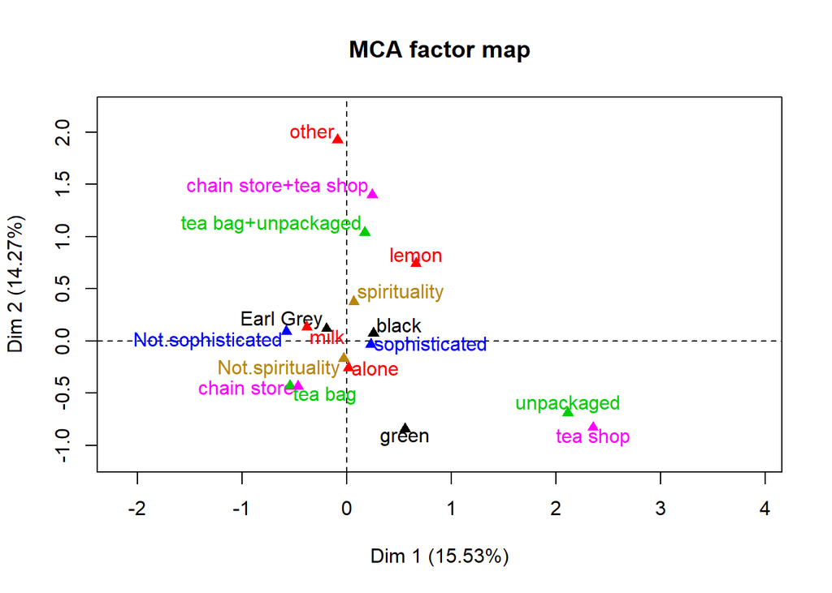

```r
keep_columns <- c("Tea", "How", "how", "sophisticated", "where", "spirituality")

tea_time <- select(tea, one_of(keep_columns))
mca <- MCA(tea_time, graph = FALSE)

plot(mca, invisible=c("ind"), habillage = "quali", graph.type = "classic")
```